# Exercise 4

Fortgeschrittene Statistische Software für NF

Akram Helal, Seyed Ramtin Hosseini  
2025-06-18

## General Remarks

- You can submit your solutions in teams of up to 3 students.
- Include all your team-member’s names and student numbers (Martrikelnummern) in the `authors` field.
- Please use the exercise template document to work on and submit your results.
- Use a level 2 heading for each new exercise and answer each subtask next to it’s bullet point or use a new level 3 heading if you want.
- Always render the R code for your solutions and make sure to include the resulting data in your rendered document.
- Submit your solution in a HTML file
- Make sure to not print more than 10 rows of data (unless specifically instructed to).
- Always submit both the rendered document(s) as well as your source Rmarkdown or Quarto document. Submit the files separately on moodle, **not** as a zip archive.
- Use echo=TRUE in your R chunks in RMarkdown or Quarto, so that your HTML files also include your code and not only your code outputs such as tables or graphs.

# Planning a city trip around Europe

## Exercise 1: Discovering Barcelona (4 Points)

We’re planning a weekend city trip around Europe and want to use geospatial data science tools to support our planning. First stop is Barcelona. We’ll work with the {osmdata} and {tmap} packages.

1. Use the appropriate function from `{osmdata}` to extract both the bounding box matrix and the polygon format for “Barcelona”. Briefly explain in 1–2 sentences why we might want to use one over the other in different mapping or data extraction scenarios.

Note: When using getbb(…, format_out = “sf_polygon”), the result is a list containing both “polygon” and “multipolygon” formats. Select the “multipolygon” object for better accuracy in boundary mapping.

The matrix format is simpler and more efficient for quick bounding-box queries or base maps, while the polygon format provides more accurate city boundaries, which is useful for precise spatial operations or when visual accuracy matters in mapping.

```r
# Installing and Loading librarys
#install.packages("osmdata")
#install.packages("tmap")

library(osmdata)
library(tmap)

# Searching for bounding box matrix and polygon formats
#?osmdata

# Bounding Box
bb_Barcelona <- getbb("Barcelona", format_out = "matrix") # matrix is default

# Polygon to Multipolygon
bb_poly_Barcelona <- getbb("Barcelona", format_out = "sf_polygon")
bb_poly_Barcelona <- bb_poly_Barcelona$multipolygon
```

### Explanation

On the one hand the bounding-box matrix is extremely fast and lightweight, which makes it ideal for fast queries. On the other hand, multipolygon boundarys captures the “true” map, with all its irregular shapes, accurate area, etc., which makes it less usefull for fast queries.

2. Create two different plots of the city outline using the polygon format: one interactive and one non-interactive. Customize the plots so that:
- The borders are shown in “darkblue”
- You add a title to each map using tm_layout
- The interactive map allows zooming and panning

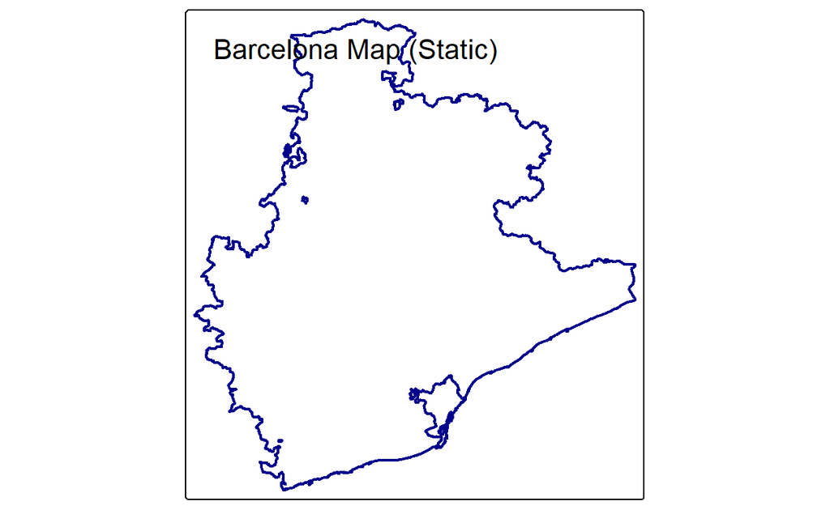

```r
# Static Plot
tmap_mode("plot")
tm_shape(bb_poly_Barcelona) +
  tm_borders(col = "darkblue", lwd = 2) +
  tm_layout(
    title = "Barcelona Map (Static)"
  )
```

```r
# Interactive View
tmap_mode("view")
tm_shape(bb_poly_Barcelona) +
  tm_borders(col = "darkblue", lwd = 2) +
  tm_layout(
    title = "Barcelona Map (Interactive)"
  )
```

[interactive chart not shown]

3. Briefly describe the pros and cons of interactive maps and non-interactive maps based on the example you created in b) with one sentence each.

### Interactive View

(+) Allows users to zoom and pan for more detailed boundary view.

(+) The interactive view also allows the users to see the map in different planes.

(-) Can be less usefull for printed documents or presentations.

(-) May require more resources.

### Non-Interactive View

(+) Produces a clean and static view of the map, which can be used for printed documents or presentation.

(-) Does not allow users to see more areas of interest or to customize the view.

4. Use the bounding box matrix to download all museums in Barcelona using the Overpass API via {osmdata}. Then display their locations on a static map using {tmap}.

Customize the map so that: - Museums are shown as red dots. - You use tm_basemap(“OpenStreetMap”) for context. - You add a title indicating it’s a map of museums.

[figure not shown]

```r
# Get all museums
bb_Barcelona_museums <- bb_Barcelona %>%
  opq() %>%
  add_osm_feature(key = "tourism", value = "museum") %>% # museums are under the key tourism
  osmdata_sf()

bb_Barcelona_museums <- bb_Barcelona_museums$osm_points

# Static Map View
tmap_mode("plot")
tm_basemap("OpenStreetMap") +
  tm_shape(bb_Barcelona_museums) +
  # Adding red dots with black borders
  tm_symbols(col = "red", size = 0.3, border.col = "black", border.lwd = 0.5) +
  tm_layout(
    title = "Museums in Barcelona",
    frame = FALSE
  )
```

5. Filter the museums to only those that have a name. Then, use {leaflet} to create an interactive map that displays a popup with each museum’s name when clicked.

Ensure the map: - Centers over Barcelona. - Uses a light basemap (e.g., CartoDB.Positron).

```r
library(leaflet)
library(dplyr)

# Removing museums without names
bb_Barcelona_museums_clean <- bb_Barcelona_museums %>%
  filter(!is.na(name))

leaflet(data = bb_Barcelona_museums_clean) %>%
  #setView(lng = center_lng, lat = center_lat, zoom = 13) %>%
  addProviderTiles(providers$CartoDB.Positron) %>%
  addMarkers(
    popup = ~name
  ) %>%
  addLegend(position = "bottomright", colors = "blue", labels = "Museums")
```

[interactive chart not shown]

## Exercise 2: Finding Accommodation in Berlin (5 Points)

Oops, we spent too much money in Barcelona. On our next stop in Berlin, we’d like to plan more budget-friendly and find a simple accommodation option such as a hostel. For this, we’ll be using OpenStreetMaps.

1. Search for the correct tag to identify *affordable accommodation* in OpenStreetMaps. Write down the tag below and add the URL to its OSMWiki page.

   Tag: tourism=hostel

   OSMWiki page: https://wiki.openstreetmap.org/wiki/Tag:tourism%3Dhostel
2. Write an {osmdata} query that downloads all hostels in Berlin using a bounding box. How many hostels are there in Berlin? Explain how you interpret points, polygons, and lines in the query results. If no lines are returned (as is often the case for buildings), explain why this is expected.

```r
# Getting bounding box for Berlin
bb_berlin <- getbb("Berlin", format_out = "matrix")

# Query for all object tagged tourism=hostel
bb_berlin <- bb_berlin %>%
  opq() %>%
  add_osm_feature(key = "tourism", value = "hostel") %>%
  osmdata_sf()

# Getting hostels
bb_berlin_points   <- nrow(bb_berlin$osm_points)
bb_berlin_polygons <- nrow(bb_berlin$osm_polygons) + nrow(bb_berlin$osm_multipolygons)
bb_berlin_lines    <- nrow(bb_berlin$osm_lines)

cat("Hostel in Berlin:\n",
    "- Points:   ", bb_berlin_points,   "\n",
    "- Polygons: ", bb_berlin_polygons, "\n",
    "- Lines:    ", bb_berlin_lines,    "\n"
    )
```

```
Hostel in Berlin:
 - Points:    708
 - Polygons:
 - Lines:
```

### Interpretation

- Points are single OSM nodes tagged as a value, where only a location marker is needed.
- Polygons represent mapped values/areas, where the item usually has a building footprint or property boundary.
- Lines would capture linear features tagged as the value. Which is very uncommon for hostels, since they are places and not linear ways. Which explains why we expected 0 or NULL.
3. Since there are quite a few hostels, we want to limit our search a bit. How many of the hostels have a name? How many also include information on the number of beds?

> Hint: If you have trouble working with the result, look at the different types of result in there. We’re only interested in osm_points here.

```r
library(dplyr)

# Removing name with NA as values
bb_berlin_has_name <- bb_berlin$osm_points %>%
  filter(!is.na(name))

cat("Only", nrow(bb_berlin_has_name), "hostels have names.\n")
```

```
Only 86 hostels have names.
```

```r
# Removing beds with NA as values
bb_berlin_has_bed <- bb_berlin$osm_points %>%
  filter(!is.na(beds))

cat("Only", nrow(bb_berlin_has_bed), "hostels have informations on beds.\n")
```

```
Only 3 hostels have informations on beds.
```

```r
# Removing name and beds with NA as values
bb_berlin_has_name_bed <- bb_berlin$osm_points %>%
  filter(!is.na(name) & !is.na(beds))

cat("Only", nrow(bb_berlin_has_name_bed), "hostels have names and informations on beds.")
```

```
Only 2 hostels have names and informations on beds.
```

4. Use tm_dots() to plot the hostels in Berlin on an *interactive* map
   - Color the dots based on the type of internet access provided by each hostel (internet_access).
   - Use the hostel’s name as the ID to display when hovering over a dot on the map.
   - Choose an appropriate color palette and add a title to the map indicating that it shows hostels in Berlin by internet access.

```r
# It was not said, that we have to use the dataframe where the hostels has names.
# We will use the hostels, where there also is a name.
bb_berlin_interactive <- bb_berlin_has_name

# factoring internet_access for legend
bb_berlin_interactive <- bb_berlin_interactive %>%
  mutate(internet_access = factor(internet_access))

# interactive map
tmap_mode("view")
tm_shape(bb_berlin_interactive) +
  tm_dots(
    col = "internet_access",
    id = "name",
    palette = "Dark2",
    title = "Internet Access"
  ) +
  tm_layout(
    title = "Hostels in Berlin by Internet Access"
  )
```

[interactive chart not shown]

5. Your grandma, who lives in Berlin, just called and said she wanted to come visit you at the hostels. Grandma is struggling with walking up stairs. Create a bar chart using {ggplot2} showing wheelchair-accessibility from the named hostels. You can use str() for the variable you saved in the previous exercise to find the proper variable for wheelchair-accessible hostels. Filter the dataset to include only hostels where wheelchair is “yes”, “limited”, or “no”. Then, represent the following:
   - “yes” for full accessibility,
   - “limited” for limited accessibility,
   - “no” for no accessibility.

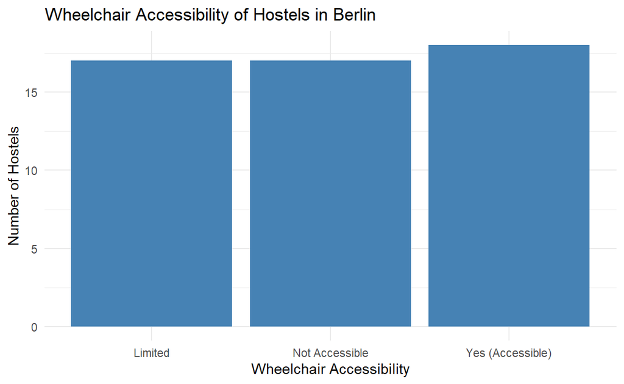

```r
library(tidyverse)

# Searching for hostels with explicit wheelchair info
bb_berlin_wheelchair <- bb_berlin_interactive %>%
  filter(wheelchair %in% c("yes", "limited", "no"))

# Plot
ggplot(
  bb_berlin_wheelchair, aes(x = wheelchair)
) +
  geom_bar(fill = "steelblue") +
  labs(
    title = "Wheelchair Accessibility of Hostels in Berlin",
    x = "Wheelchair Accessibility",
    y = "Number of Hostels"
  ) +
  scale_x_discrete(
    labels = c("yes" = "Yes (Accessible)", "limited" = "Limited", "no" = "Not Accessible")
  ) +
  theme_minimal()
```

6. We’re almost done! Lastly, select one of the hostels that you find appealing and return only its row in the data. What’s the name of the hostel you chose and why did you choose this one?

```r
# Filter for hotels with wheelchair (yes) for grandma and internet_access
selected_hostel <- bb_berlin_interactive %>%
  filter((wheelchair %in% "yes") & internet_access %in% c("wlan", "yes"))

# Selecting one Hostel
selected_hostel <- selected_hostel %>%
  filter(osm_id == 3098126874)
```

[output not shown]

We chosed The Circus Hostel, because we like the Circus. It has wheelchair accessability for grandma and internet access.

## Exercise 3: It’s coming home (6 Points)

In this exercise you will analyze and visualize some datasets, that contain information on every professional football match played in the UK since 1888. You can access the data via this GitHub repository: https://github.com/jfjelstul/englishfootball

```r
knitr::opts_chunk$set(dev = "ragg_png")

#install.packages("gganimate")
library(gganimate)
library(gifski)
```

1. Load the `{matches.csv}` file from the `{data}` folder. Visualize how the number of total goals scored per game has evolved over time. Create a nice and complete plot and interpret what you see in one or two sentences.

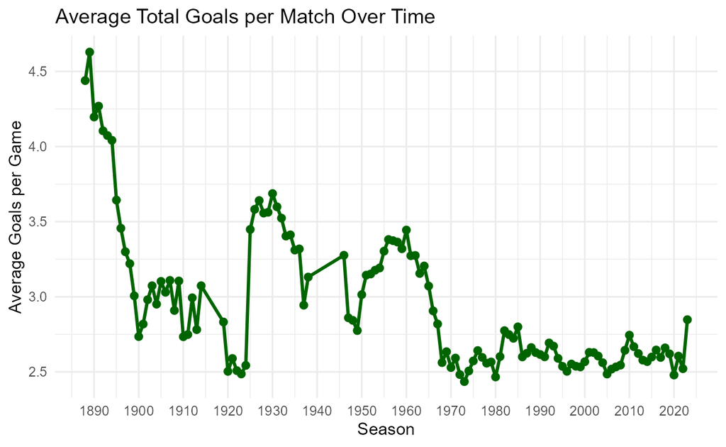

```r
# Installing data
matches <- readr::read_csv(
  "https://raw.githubusercontent.com/jfjelstul/englishfootball/master/data-csv/matches.csv"
)

# Compute total goals in each match and extract season’s start year
matches <- matches %>%
  mutate(
    total_goals  = home_team_score + away_team_score,
    season_start = as.integer(str_sub(season, 1, 4))
  )

# average goals per game by season
goals_by_season <- matches %>%
  group_by(season_start) %>%
  summarize(avg_goals = mean(total_goals, na.rm = TRUE))

# Plot static
game_static <- ggplot(goals_by_season, aes(x = season_start, y = avg_goals)) +
  geom_line(color = "darkgreen", size = 1) +
  geom_point(color = "darkgreen", size = 2) +
  scale_x_continuous(breaks = seq(1890, 2020, by = 10)) +
  labs(
    title = "Average Total Goals per Match Over Time",
    x     = "Season",
    y     = "Average Goals per Game"
  ) +
  theme_minimal()

game_static
```

### Interpretation

We can see, that the average goals per game started high, then it went down. During the interwar years it went higher, but went again lower and now it swings around 2,65 goals per game.

2. Now create an animated version of your plot and include the GIF in your HTML

```r
# Dynamic Plot
game_animated_plot <- game_static + transition_reveal(along = season_start)

# creating animation
game_anim <- animate(
  game_animated_plot,
  duration = 10,          # Duration in seconds
  fps      = 15,
  width    = 800,
  height   = 400,
  renderer = gifski_renderer(loop = TRUE)
)

anim_save("matches_animation.gif", animation = game_anim)
```

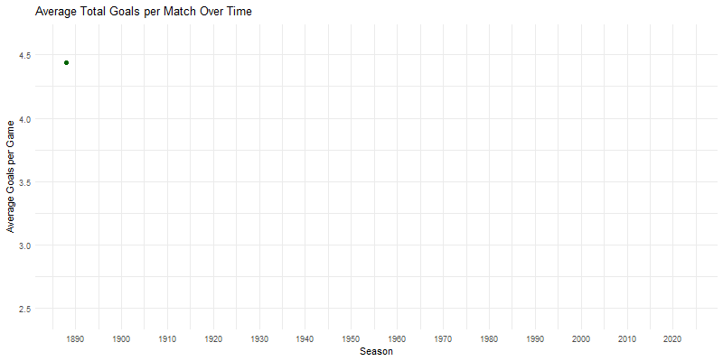

```r
knitr::include_graphics("matches_animation.gif")
```

3. Load the `{standings.csv}` dataset. We will now analyze how Liverpool FC has performed over the years. Create an animated plot that contains the number of points and the final placement of LFC for every year they have participated in professional football. The exact visualization is up to you.

```r
# Loading the data
standings <- read_csv(
  "https://raw.githubusercontent.com/jfjelstul/englishfootball/master/data-csv/standings.csv"
)

# Filtering for Liverpool FC
lfc <- standings %>%
  filter(team_name == "Liverpool")

lfc <- lfc %>%
  mutate(year = as.integer(substr(season, 1, 4)))

lfc_long <- lfc %>%
  select(year, points, position, season) %>%
  pivot_longer(
    cols      = c(points, position),
    names_to  = "metric",
    values_to = "value"
  )

# Plot
lfc_plot <- ggplot(lfc_long, aes(x = year, y = value, color = metric)) +
  geom_line(size = 1) +
  geom_point(size = 2) +
  facet_wrap(~ metric, scales = "free_y", ncol = 1,
             labeller = as_labeller(c(points = "Points", position = "Final Position"))) +
  scale_x_continuous(breaks = seq(min(lfc_long$year), max(lfc_long$year), by = 5)) +
  scale_color_manual(values = c(points = "firebrick", position = "steelblue")) +
  labs(
    title = "Liverpool FC Performance — Season {frame_along}",
    x     = "Season (start year)",
    y     = NULL,
    color = NULL
  ) +
  theme_minimal(base_size = 14) +
  theme(
    strip.text   = element_text(face = "bold", size = 12),
    plot.title   = element_text(face = "bold", size = 16, hjust = 0.5),
    axis.text.x  = element_text(angle = 45, hjust = 1)
  )
```

```r
# Animation
lfc_plot_anim <- lfc_plot + transition_reveal(year) # Animate over the 'year' variable

  lfc_performance <- animate(
    lfc_plot_anim,
    fps      = 10,
    duration = 12,
    width    = 600,
    height   = 600,
    renderer = gifski_renderer(loop = TRUE)
  )

anim_save("lfc_performance.gif", animation = lfc_performance)
```

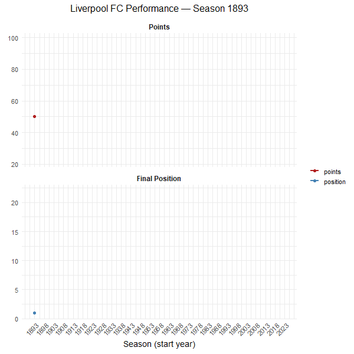

```r
knitr::include_graphics("lfc_performance.gif")
```

4. Adjust the velocity of your animations. Also change one of your axes with respect to being fixed or not.

```r
# Animation
# More fps and more duration
lfc_plot_anim_2 <- lfc_plot + transition_reveal(year) # Animate over the 'season' variable

  lfc_performance_2 <- animate(
    lfc_plot_anim_2,
    fps      = 30,
    duration = 15,
    width    = 600,
    height   = 600,
    renderer = gifski_renderer(loop = TRUE)
  )

anim_save("lfc_performance_2.gif", animation = lfc_performance_2)
```

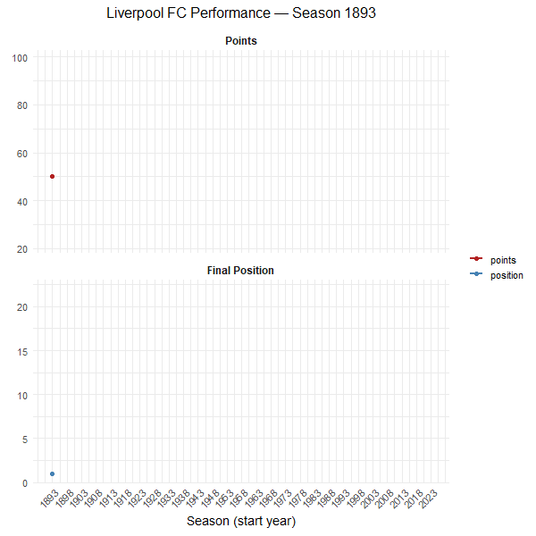

```r
knitr::include_graphics("lfc_performance_2.gif")
```